# Broad-sense community heritability

Applying model-based approaches to the calculation of broad-sense community heritability

true  
November 5, 2021

## Setting the scene

Broad-sense community heritability extends the concept of broad-sense heritability to cummunity level. In practice, it allows us to understand whether to host genotypic variation corresponds variation in a community of interacting organisms (Whitham et al. 2006). It is important because it provides evidence of community selection (Whitham et al. 2020). Debate about whether selection acts at individual level or community level is a very heated argument among evolutionary biologists.

Despite being an important matric in the context of evolution, its calculation method is not optimal. Following the official calculation method proposed by Whytam et al., (Whitham et al. 2006), broad-sense community heritability is calculated as follow:

1. apply NMDS to community data. For example, this can be an OTU table or arthropod community associated with different trees. The important thing is that you need to have several tree genotypes which are replicated. For example, you have 3 replicate of genotype A, 3 replicate of genotype B and so forth. Replicates need to be genotypically identic to each other, thus they need to be clones.
2. Perform an ANOVA on the NMDS scores, having plant genotype as explanatory variable. The resulting R^2 will tell you the heritability value and the the significance.

## Idea of the paper

The idea of the paper would be to apply the above mentioned method to different experiments, including arthropod data and microbiome data and highlight the statistical problem related this approach. We then propose to calculate broad-sense community heritability with mvabund.

My idea was to make a short paper that would fit under the category of brief communication for Nature method (https://www.nature.com/nmeth/content) or Nature in ecology and evolution (https://www.nature.com/natecolevol/content). Let me know what you think

## Community heritability calculated on arthropod community

This is how the data look like. We have replicates of different tree genotypes and for each tree we have community data

```r
paged_table(arth_df)
```

| Tree | Genotype | Pemphigus.betae | Phyllacolpa.sp.1 | Phylloctnistis.sp.1 | Phylloctnistis.sp.2 | Tortricidae.sp.1 | Tortricidae.sp.2 | Anacampsis.niveopulvella | Paraleucoptera.albella | Tortricidae.sp.3 | Pemphigus.populiglobuli | Gypsonoma.haimbachiana | Thecabius.populimonilis |
| --- | --- | --- | --- | --- | --- | --- | --- | --- | --- | --- | --- | --- | --- |
| N4-24 | 10 | 21 | 0 | 1 | 0 | 0 | 0 | 0 | 0 | 0 | 3 | 0 | 0 |
| N5-17 | 10 | 5 | 7 | 1 | 2 | 0 | 1 | 0 | 0 | 0 | 0 | 0 | 0 |
| N6-10 | 10 | 2 | 5 | 0 | 0 | 0 | 0 | 0 | 1 | 0 | 0 | 0 | 0 |
| N7-10 | 10 | 2 | 6 | 0 | 0 | 0 | 0 | 0 | 1 | 0 | 0 | 1 | 0 |
| N1-36 | 11 | 6 | 12 | 0 | 0 | 0 | 1 | 0 | 0 | 0 | 0 | 0 | 0 |
| N2-35 | 11 | 9 | 25 | 0 | 2 | 0 | 0 | 0 | 0 | 0 | 0 | 0 | 0 |
| N4-30 | 11 | 6 | 3 | 1 | 1 | 0 | 0 | 0 | 0 | 0 | 0 | 0 | 0 |
| N1-34 | 996 | 2 | 2 | 0 | 3 | 0 | 0 | 0 | 0 | 0 | 0 | 0 | 0 |
| N2-16 | 996 | 2 | 10 | 0 | 4 | 0 | 0 | 0 | 0 | 0 | 0 | 0 | 0 |
| N2-29 | 996 | 0 | 2 | 0 | 3 | 0 | 0 | 1 | 0 | 0 | 0 | 0 | 0 |

[output cut: 68 more lines]

### Traditional approach

One problem of this method already is that if you force NMDS to have 1 axes only, it will not converge. Thus, the only way is to calculate 2 axes and then use the first one for the calculation of heritability.

```r
#arth_NMDS=metaMDS(arth_matrix,k=2,trymax=5000)
```

Final table

```r
arth_NMDS_scs <- data.frame(arth_NMDS$points) %>%
  select(-2) %>%
  rownames_to_column(var="Tree") %>%
    left_join(select(arth_df, 1:2)) %>%
    mutate(Genotype=as.factor(Genotype))

paged_table(arth_NMDS_scs)
```

| Tree | MDS1 | Genotype |
| --- | --- | --- |
| N4-24 | -0.44026474 | 10 |
| N5-17 | -0.20386116 | 10 |
| N6-10 | 0.68770717 | 10 |
| N7-10 | 0.68941486 | 10 |
| N1-36 | 0.54493138 | 11 |
| N2-35 | 0.18843942 | 11 |
| N4-30 | -0.19094473 | 11 |
| N1-34 | -0.00704507 | 996 |
| N2-16 | 0.11037630 | 996 |
| N2-29 | -0.46300521 | 996 |

[output cut: 68 more lines]

```r
arth_lm <- lm(MDS1~Genotype, data=arth_NMDS_scs)

RsquareAdj(arth_lm)
```

```
$r.squared
[1] 0.4883317

$adj.r.squared
[1] 0.2423373
```

```r
anova(arth_lm)
```

```
Analysis of Variance Table

Response: MDS1
          Df Sum Sq Mean Sq F value  Pr(>F)
Genotype  25 7.9492 0.31797  1.9851 0.01867 *
Residuals 52 8.3290 0.16017
---
Signif. codes:  0 '***' 0.001 '**' 0.01 '*' 0.05 '.' 0.1 ' ' 1
```

### mvabund approach

Applying the MGLM. David, could you confirm that unbalance design is not a problem?

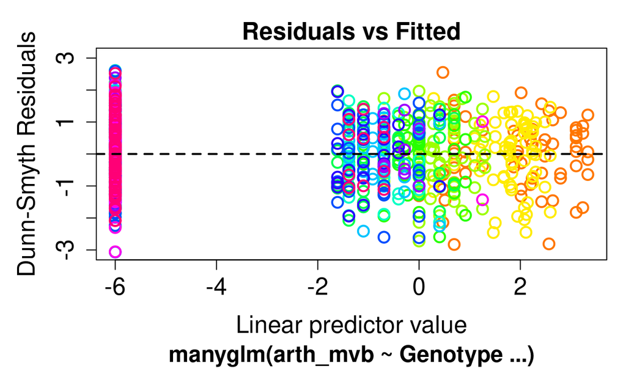

```r
arth_mvb <- mvabund(arth_matrix)

arth_MGLM <- manyglm(arth_mvb~ Genotype, data = arth_df)

plot(arth_MGLM)
```

Heritability is 20%

```r
arth_int <- manyglm(arth_mvb~ 1) # intercept only model

null_dev_arth <- -2*sum(logLik(arth_int))

res_dev_arth <- -2*sum(logLik(arth_MGLM))

((null_dev_arth-res_dev_arth)/null_dev_arth)*100
```

```
[1] 20.84233
```

and it is significant

```r
(arth_mvb_out <- anova(arth_MGLM, nBoot = 999))
```

```
Time elapsed: 0 hr 8 min 17 sec
```

```
Analysis of Deviance Table

Model: arth_mvb ~ Genotype

Multivariate test:
            Res.Df Df.diff   Dev Pr(>Dev)
(Intercept)     77
Genotype        52      25 405.5    0.001 ***
---
Signif. codes:  0 '***' 0.001 '**' 0.01 '*' 0.05 '.' 0.1 ' ' 1
Arguments:
 Test statistics calculated assuming uncorrelated response (for faster computation)
 P-value calculated using 999 iterations via PIT-trap resampling.
```

## Community heritability calculated on endophytes

### traditional approach

We basically do the same thing as before. We calculate NMDS1 score and apply ANOVA

```r
ends_df <- read_excel("../data/Lamit_CWGenotypeForHeritabilityMethods.xlsx", sheet = 4)

paged_table(ends_df)
```

| Tree | Genotype | Ogden_08 | AltComp2006 | Ogden_22 | Ogden_06 | Ogden_12 | Ogden_09 | Ogden_15 | Ogden_32 | Ogden_10 | Ogden_30 | Ogden_20 | Ogden_21 | Constant |
| --- | --- | --- | --- | --- | --- | --- | --- | --- | --- | --- | --- | --- | --- | --- |
| N4-24 | 10 | 0 | 0 | 1 | 0 | 0 | 0 | 0 | 0 | 0 | 0 | 0 | 0 | 1 |
| N5-17 | 10 | 1 | 1 | 0 | 1 | 0 | 0 | 0 | 0 | 0 | 0 | 0 | 0 | 1 |
| N6-10 | 10 | 0 | 1 | 2 | 3 | 0 | 0 | 0 | 0 | 0 | 0 | 0 | 0 | 1 |
| N7-10 | 10 | 1 | 1 | 2 | 1 | 0 | 0 | 0 | 0 | 1 | 0 | 0 | 0 | 1 |
| N1-10 | 996 | 9 | 1 | 1 | 0 | 0 | 0 | 0 | 0 | 0 | 0 | 0 | 0 | 1 |
| N1-34 | 996 | 1 | 2 | 3 | 1 | 1 | 0 | 0 | 0 | 0 | 0 | 0 | 0 | 1 |
| N2-04 | 996 | 1 | 0 | 1 | 1 | 2 | 0 | 0 | 0 | 0 | 0 | 0 | 0 | 1 |
| N2-10 | 996 | 1 | 2 | 1 | 2 | 1 | 0 | 0 | 0 | 0 | 0 | 0 | 0 | 1 |
| N2-22 | 996 | 0 | 2 | 4 | 1 | 2 | 0 | 0 | 0 | 0 | 0 | 0 | 0 | 1 |
| N3-06 | 996 | 3 | 1 | 0 | 0 | 0 | 0 | 0 | 0 | 0 | 0 | 1 | 0 | 1 |

[output cut: 39 more lines]

```r
ends_NMDS_scs <- data.frame(ends_NMDS$points) %>%
    select(-2) %>%
    rownames_to_column(var="Tree") %>%
    left_join(select(ends_df, 1:2)) %>%
    mutate(Genotype=as.factor(Genotype))

paged_table(ends_NMDS_scs)
```

| Tree | MDS1 | Genotype |
| --- | --- | --- |
| N4-24 | -0.551680077 | 10 |
| N5-17 | -0.109994765 | 10 |
| N6-10 | 0.091161213 | 10 |
| N7-10 | 0.176485675 | 10 |
| N1-10 | -0.174921390 | 996 |
| N1-34 | 0.208750278 | 996 |
| N2-04 | 0.271401618 | 996 |
| N2-10 | 0.272892221 | 996 |
| N2-22 | 0.354278896 | 996 |
| N3-06 | 0.037225206 | 996 |

[output cut: 39 more lines]

Heritability is 18% but it is not significant

```r
ends_lm <- lm(MDS1~Genotype, data=ends_NMDS_scs)

RsquareAdj(ends_lm)
```

```
$r.squared
[1] 0.1859139

$adj.r.squared
[1] -0.001952077
```

```r
anova(ends_lm)
```

```
Analysis of Variance Table

Response: MDS1
          Df Sum Sq Mean Sq F value Pr(>F)
Genotype   9 1.0540 0.11711  0.9896 0.4641
Residuals 39 4.6151 0.11834
```

### mvabund approach

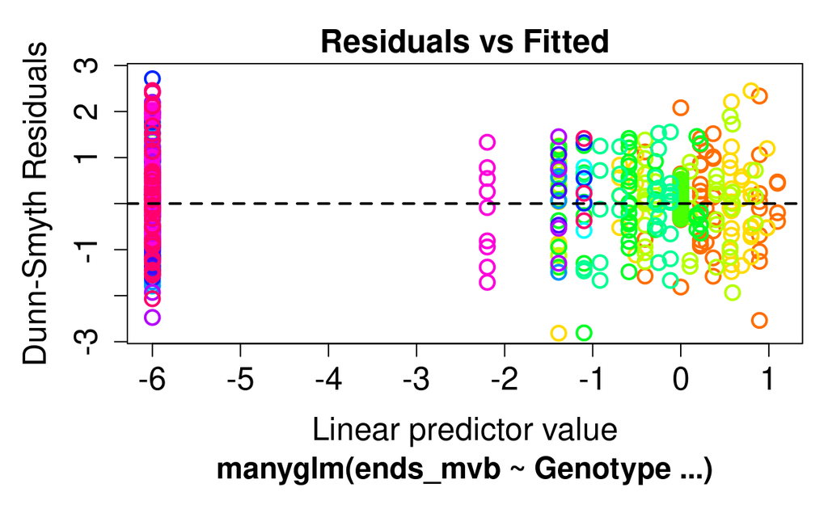

```r
ends_mvb <- mvabund(ends_matrix)

ends_MGLM <- manyglm(ends_mvb~ Genotype, data = ends_df)

plot(ends_MGLM)
```

```r
# for significance of heritability

(ends_mvb_out <- anova(ends_MGLM, nBoot = 999))
```

```
Time elapsed: 0 hr 5 min 8 sec
```

```
Analysis of Deviance Table

Model: ends_mvb ~ Genotype

Multivariate test:
            Res.Df Df.diff   Dev Pr(>Dev)
(Intercept)     48
Genotype        39       9 108.5     0.01 **
---
Signif. codes:  0 '***' 0.001 '**' 0.01 '*' 0.05 '.' 0.1 ' ' 1
Arguments:
 Test statistics calculated assuming uncorrelated response (for faster computation)
 P-value calculated using 999 iterations via PIT-trap resampling.
```

```r
# Heritability calculation

ends_int <- manyglm(ends_mvb~ 1) # intercept only model

null_dev_ends <- -2*sum(logLik(ends_int))

res_dev_ends <- -2*sum(logLik(ends_MGLM))

((null_dev_ends-res_dev_ends)/null_dev_ends)*100
```

```
[1] 13.38471
```

## Community heritability calculated on microbiome

### traditional approach

This dataset will be published soon. Basically, it represents the microbiome of different common bean genotypes grown in a greenhouse (complete randomization) with about 7 replicate each.

```r
mcrb_df <- read_csv("../data/otu_table.csv")

paged_table(mcrb_df)
```

| Sample_ID | SV_1 | SV_2 | SV_5 | SV_6 | SV_7 | SV_8 | SV_9 | SV_10 | SV_11 | SV_13 | SV_14 | SV_15 | SV_17 | SV_18 | SV_19 | SV_21 | SV_23 | SV_26 | SV_29 | SV_30 | SV_31 | SV_32 | SV_34 | SV_35 | SV_36 | SV_37 | SV_39 | SV_40 | SV_41 | … |
| --- | --- | --- | --- | --- | --- | --- | --- | --- | --- | --- | --- | --- | --- | --- | --- | --- | --- | --- | --- | --- | --- | --- | --- | --- | --- | --- | --- | --- | --- | --- |
| G22309-1 | 7150 | 5934 | 7745 | 6990 | 1736 | 3538 | 2978 | 3400 | 1179 | 3016 | 367 | 280 | 1457 | 1231 | 1314 | 871 | 287 | 252 | 0 | 0 | 934 | 350 | 0 | 697 | 287 | 233 | 0 | 1253 | 155 | … |
| G22309-2 | 2152 | 2056 | 10048 | 9551 | 1572 | 5560 | 5082 | 953 | 1302 | 854 | 2745 | 2500 | 320 | 0 | 234 | 0 | 748 | 752 | 1192 | 1131 | 0 | 2 | 0 | 0 | 0 | 656 | 0 | 0 | 661 | … |
| G22309-3 | 3628 | 3120 | 17095 | 14666 | 7360 | 2611 | 2064 | 8682 | 5609 | 7355 | 248 | 162 | 3295 | 1936 | 2769 | 1608 | 1172 | 1182 | 526 | 446 | 678 | 803 | 0 | 546 | 693 | 389 | 0 | 126 | 291 | … |
| G22309-4 | 4691 | 3885 | 15465 | 13222 | 11686 | 5037 | 4181 | 6542 | 9006 | 5279 | 356 | 314 | 2095 | 1253 | 1878 | 892 | 2007 | 1754 | 1580 | 1313 | 145 | 0 | 522 | 100 | 0 | 802 | 422 | 1740 | 718 | … |
| G22309-5 | 885 | 581 | 20709 | 17047 | 15206 | 9311 | 7135 | 7121 | 11067 | 5792 | 379 | 249 | 3807 | 1821 | 3151 | 1624 | 1166 | 968 | 95 | 72 | 62 | 2740 | 0 | 0 | 1998 | 2316 | 0 | 271 | 1999 | … |
| G22309-6 | 4899 | 4029 | 10043 | 8284 | 6574 | 723 | 545 | 6179 | 4879 | 5042 | 0 | 124 | 3137 | 2793 | 2569 | 2139 | 2889 | 2549 | 1776 | 1458 | 939 | 445 | 0 | 895 | 425 | 132 | 0 | 814 | 89 | … |
| G22309-7 | 3973 | 3528 | 9271 | 8154 | 5875 | 1188 | 863 | 4404 | 4481 | 3918 | 1044 | 830 | 792 | 1977 | 741 | 1545 | 1027 | 861 | 355 | 256 | 1513 | 0 | 0 | 1228 | 51 | 226 | 0 | 0 | 170 | … |
| G23419-1 | 20218 | 18103 | 2282 | 2093 | 1538 | 1552 | 1367 | 1501 | 1114 | 1315 | 296 | 273 | 568 | 545 | 598 | 400 | 210 | 190 | 0 | 0 | 0 | 47 | 0 | 0 | 25 | 0 | 0 | 132 | 0 | … |
| G23419-2 | 18177 | 15667 | 4708 | 4400 | 3194 | 1449 | 1211 | 2575 | 1534 | 2246 | 280 | 157 | 197 | 431 | 200 | 366 | 66 | 53 | 93 | 68 | 0 | 0 | 0 | 0 | 0 | 315 | 0 | 625 | 278 | … |
| G23419-3 | 16218 | 14009 | 3877 | 3350 | 2785 | 794 | 673 | 1393 | 2157 | 1188 | 78 | 63 | 388 | 526 | 369 | 401 | 537 | 514 | 719 | 710 | 958 | 193 | 0 | 913 | 173 | 632 | 0 | 398 | 605 | … |

[output cut: 42 more lines]

```r
mcrb_NMDS_scs <- data.frame(mcrb_NMDS$points) %>%
    select(-2) %>%
    rownames_to_column(var="Sample_ID") %>%
    left_join(select(mcrb_df,Sample_ID,Accession))

paged_table(mcrb_NMDS_scs)
```

| Sample_ID | MDS1 | Accession |
| --- | --- | --- |
| G22309-1 | -0.36510672 | G22309 |
| G22309-2 | 0.24714164 | G22309 |
| G22309-3 | -0.22709493 | G22309 |
| G22309-4 | 0.02757437 | G22309 |
| G22309-5 | -0.10232698 | G22309 |
| G22309-6 | -0.44689576 | G22309 |
| G22309-7 | -0.02582047 | G22309 |
| G23419-1 | -0.04193326 | G23419 |
| G23419-2 | 0.13398142 | G23419 |
| G23419-3 | -0.07833342 | G23419 |

[output cut: 42 more lines]

```r
# community heritability is 20% and non significant

mcrb_lm <- lm(MDS1~Accession, data=mcrb_NMDS_scs)

RsquareAdj(mcrb_lm)
```

```
$r.squared
[1] 0.2116757

$adj.r.squared
[1] 0.08626042
```

```r
anova(mcrb_lm)
```

```
Analysis of Variance Table

Response: MDS1
          Df Sum Sq Mean Sq F value Pr(>F)
Accession  7  8.687 1.24102  1.6878  0.137
Residuals 44 32.353 0.73529
```

### mvabund approach

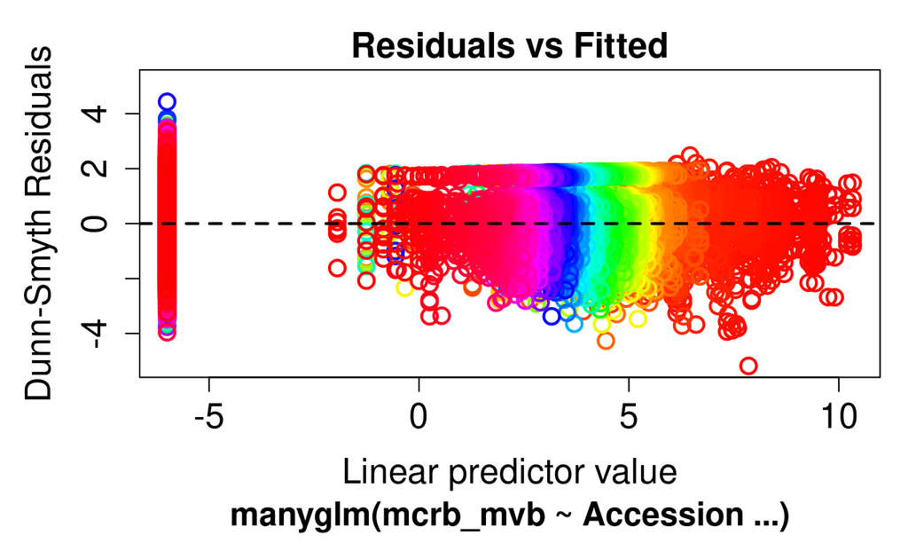

```r
mcrb_mvb <- mvabund(mcrb_matrix)
mcrb_MGLM <- manyglm(mcrb_mvb ~ Accession, data = mcrb_df)

plot(mcrb_MGLM)
```

Heritability is 8% but it is significant

```r
# Heritability calculation

mcrb_int <- manyglm(mcrb_mvb~ 1) # intercept only model

null_dev_mcrb <- -2*sum(logLik(mcrb_int))

res_dev_mcrb <- -2*sum(logLik(mcrb_MGLM))

((null_dev_mcrb-res_dev_mcrb)/null_dev_mcrb)*100
```

```
[1] 8.159949
```

We are running mvabund in multicore to speed up the process

```r
# for significance of heritability
mcrb_mvb_out <- mclapply (1:7, function(x) {

anova(mcrb_MGLM, nBoot = 30, show.time = "all")

}, mc.cores = 7)

K=7 # cores
N=30  #bootstrapping

pi_acc <- map_dbl(mcrb_mvb_out, ~ .x$table[2,4])
piMean_acc = mean(pi_acc)
(p_acc = piMean_acc + (piMean_acc-1)*(K-1)/(K*N+1)) # Accession is significant
```

```
[1] 0.004739336
```

### Conclusion

I think we have no problem to justify why using the NMDS approach is not good. In terms of result comparison it seems to be that the heritability measure is always lower when calculated with mvabund, but mvabund gives more often a statistical significance.

Whitham, Thomas G., Gerard J. Allan, Hillary F. Cooper, and Stephen M. Shuster. 2020. “Intraspecific Genetic Variation and Species Interactions Contribute to Community Evolution.” *Annual Review of Ecology, Evolution, and Systematics* 51 (1): 587–612. https://doi.org/10.1146/annurev-ecolsys-011720-123655.

Whitham, Thomas G., Joseph K. Bailey, Jennifer A. Schweitzer, Stephen M. Shuster, Randy K. Bangert, Carri J. LeRoy, Eric V. Lonsdorf, et al. 2006. “A Framework for Community and Ecosystem Genetics: From Genes to Ecosystems.” *Nature Reviews Genetics* 7 (7): 510–23. https://doi.org/10.1038/nrg1877.